# PROJECT-412-DENİZCAN-TAŞDELEN

Defining cross validation and the grid.

```r
set.seed(10)
tr_control <- trainControl(method="repeatedcv", number=10, repeats=5, search="random")

grid = expand.grid(C = seq(0, 2.5, length =12))
```

```r
set.seed(11)
svmlinearFit <- train(price~., data=train_nnet,
                      trControl=tr_control,
                      method = "svmLinear", savePredictions = T,
                      tuneGrid=grid)
```

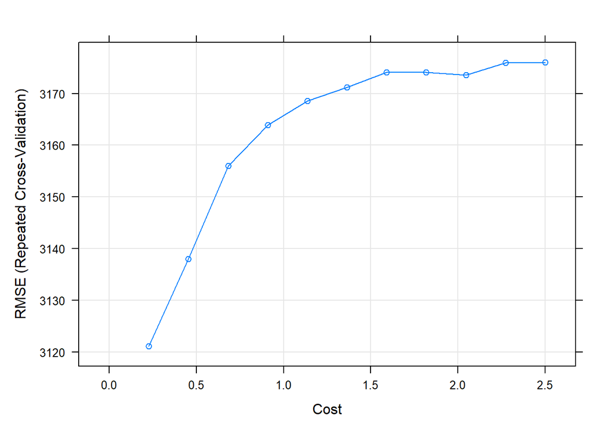

```r
plot(svmlinearFit)
```

Below graphs show that although SVM is successful in predicting the train dataset points, test results are far from the actual test set points. Hence, SVM is not good for our dataset.

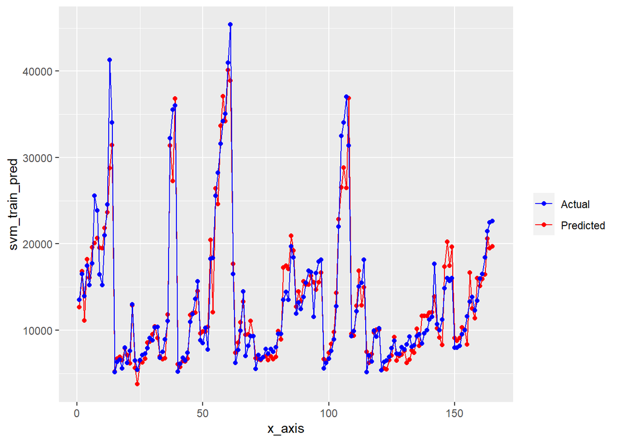

```r
numx <- nrow(train_nnet)
x_axis <- seq(numx)
svm_train_pred<-predict(svmlinearFit,newdata = train_nnet)
df <- data.frame(x_axis, svm_train_pred,train_nnet$price)
#Plotting the predicted values against the actual values
g <- ggplot(df, aes(x=x_axis))
g <- g + geom_line(aes(y=svm_train_pred, colour="Predicted"))
g <- g + geom_point(aes(x=x_axis, y=svm_train_pred, colour="Predicted"))
g <- g + geom_line(aes(y=train_nnet$price, colour="Actual"))
g <- g + geom_point(aes(x=x_axis, y=train_nnet$price, colour="Actual"))
g <- g + scale_colour_manual("", values = c(Predicted="red", Actual="blue"))
g
```

```r
svm_linear_var_imp<-varImp(svmlinearFit, scale = FALSE)
svm_linear_var_imp
```

```
## loess r-squared variable importance
##
##   only 20 most important variables shown (out of 28)
##
##                      Overall
## enginesize            0.7680
## curbweight            0.7098
## horsepower            0.6935
## carwidth              0.6345
## carlength             0.4993
## highwaympg            0.4979
## citympg               0.4877
## wheelbase             0.4338
## cylindernumber.four   0.4320
## drivewheel.rwd        0.3826
## boreratio             0.3807
## drivewheel.fwd        0.3384
## CarName.buick         0.2904
## fuelsystem.mpfi       0.2612
## cylindernumber.eight  0.2532
## fuelsystem.2bbl       0.2141
## cylindernumber.six    0.1774
## enginetype.ohc        0.1417
## CarName.porsche       0.1320
## carheight             0.1306
```

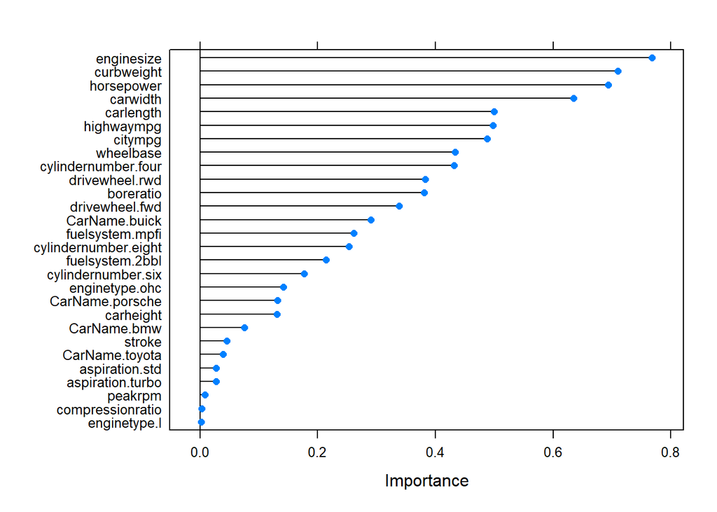

```r
plot(svm_linear_var_imp)
```

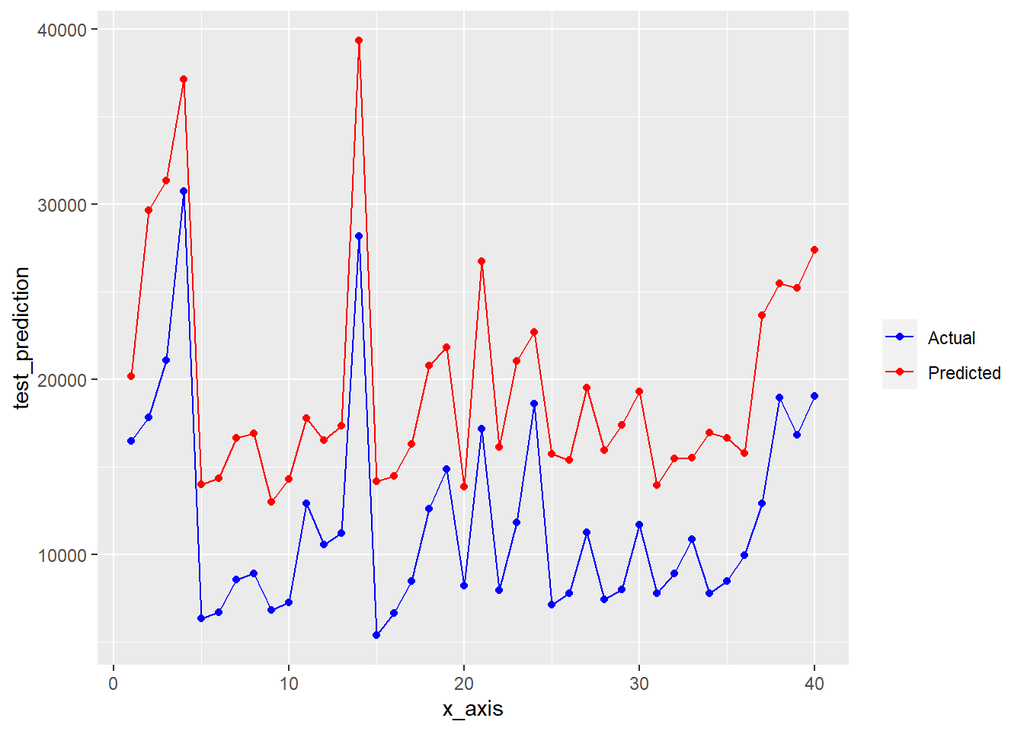

```r
test_prediction<-predict(svmlinearFit,newdata= test_nnet)

numx <- nrow(test_nnet)
x_axis <- seq(numx)
df <- data.frame(x_axis,test_prediction,test_nnet$price)
#Plotting the predicted values against the actual values
g <- ggplot(df, aes(x=x_axis))
g <- g + geom_line(aes(y=test_prediction, colour="Predicted"))
g <- g + geom_point(aes(x=x_axis, y=test_prediction, colour="Predicted"))
g <- g + geom_line(aes(y=test_nnet$price, colour="Actual"))
g <- g + geom_point(aes(x=x_axis, y=test_nnet$price, colour="Actual"))
g <- g + scale_colour_manual("", values = c(Predicted="red", Actual="blue"))
g
```

MAE, MSE, RMSE and MAPE values are stored.

```r
#MAE, MSE, RMSE and MAPE values for train set.
svm_tr_1 <- MAE(as.numeric(svm_train_pred),train_nnet$price)
svm_tr_2 <- MSE(as.numeric(svm_train_pred),train_nnet$price)
svm_tr_3 <- RMSE(as.numeric(svm_train_pred),train_nnet$price)
svm_tr_4 <- MAPE(as.numeric(svm_train_pred),train_nnet$price)
svm_tr_2
```

```
## [1] 5837534
```

```r
#MAE, MSE, RMSE and MAPE values for train set.
svm_ts_1 <- MAE(as.numeric(test_prediction),test_nnet$price)
svm_ts_2 <- MSE(as.numeric(test_prediction),test_nnet$price)
svm_ts_3 <- RMSE(as.numeric(test_prediction),test_nnet$price)
svm_ts_4 <- MAPE(as.numeric(test_prediction),test_nnet$price)
svm_ts_2
```

```
## [1] 61691257
```

**Decision Tree-Random Forest-XGBoost Regression**

Decision Tree algorithms are used to classify points by comparing features step-by-step with each other. Starting from the root node, algorithm compares every attribute with each other until reaching the leaf node.

**Decision Tree**

```r
set.seed(9685)
fitcontrol<- trainControl(method = "repeatedcv",
                          number = 10,
                          repeats = 5,
                          summaryFunction = defaultSummary,
                          search = "random")
```

```r
set.seed(1104)
## Warning: package 'rpart' was built under R version 4.1.3
cartFit <- train(price~.,data = train.data,  method = "rpart",trControl = fitcontrol,metric="RMSE")
```

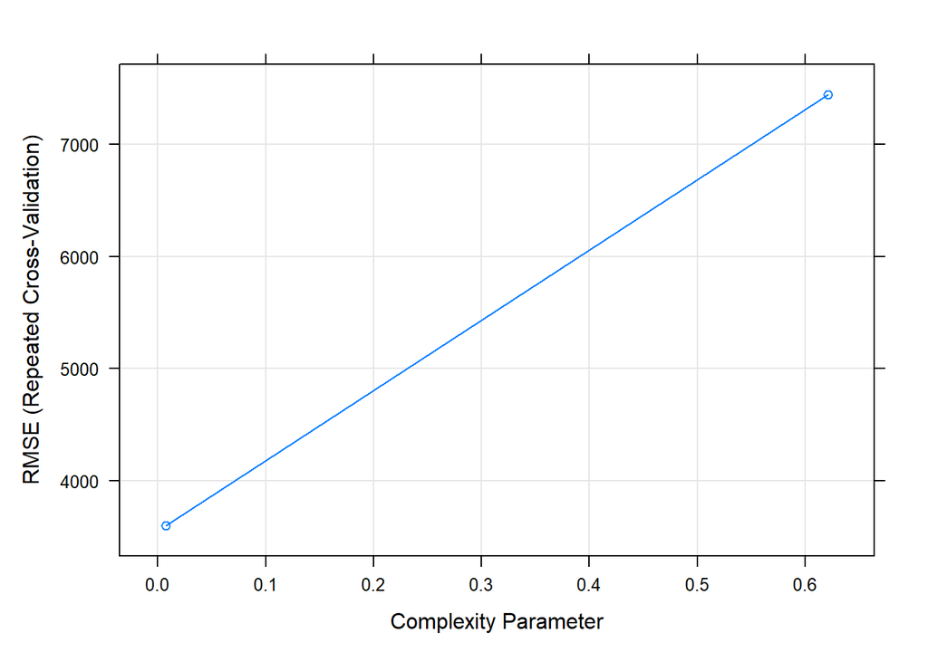

```r
plot(cartFit)
```

Basic Tree structure of the DT model for our dataset can be seen below. It states that the average car price in the overall dataset is $14.000. Average price of the cars having enginesize greater than 182 is $33.000 and they constitutes only 10% of the whole dataset. Other 90% of the cars have engine size less than 182 and average price for them is $11.000. Cars having enginesize less than 182 and curbweight less than 2571 constitutes 58% of the whole dataset and they have average price of 8.530. The interpretation continues so on.

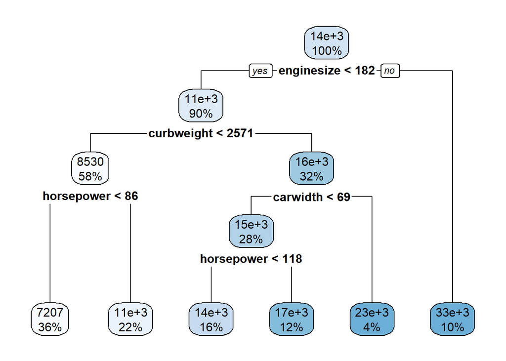

```r
rpart.plot::rpart.plot(cartFit$finalModel)
```

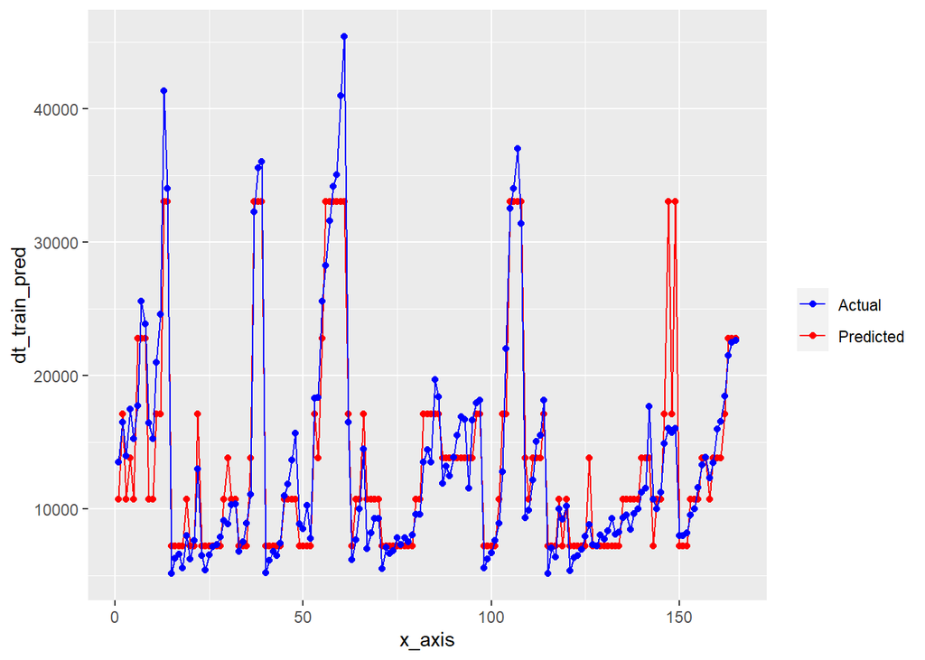

```r
numx <- nrow(train.data)
x_axis <- seq(numx)
dt_train_pred<-predict(cartFit,newdata = train.data)
df <- data.frame(x_axis, dt_train_pred,train.data$price)
#Plotting the predicted values against the actual values
g <- ggplot(df, aes(x=x_axis))
g <- g + geom_line(aes(y=dt_train_pred, colour="Predicted"))
g <- g + geom_point(aes(x=x_axis, y=dt_train_pred, colour="Predicted"))
g <- g + geom_line(aes(y=train.data$price, colour="Actual"))
g <- g + geom_point(aes(x=x_axis, y=train.data$price, colour="Actual"))
g <- g + scale_colour_manual("", values = c(Predicted="red", Actual="blue"))
g
```

```r
dt_var_imp<-varImp(cartFit, scale = FALSE)
dt_var_imp
```

```
## rpart variable importance
##
##   only 20 most important variables shown (out of 28)
##
##                      Overall
## horsepower            1.9767
## curbweight            1.6547
## highwaympg            1.4699
## citympg               1.0555
## enginesize            0.9298
## carwidth              0.8995
## wheelbase             0.6841
## carlength             0.5546
## drivewheel.rwd        0.1727
## carheight             0.0000
## enginetype.ohc        0.0000
## cylindernumber.eight  0.0000
## CarName.porsche       0.0000
## fuelsystem.2bbl       0.0000
## boreratio             0.0000
## stroke                0.0000
## cylindernumber.four   0.0000
## aspiration.std        0.0000
## CarName.buick         0.0000
## compressionratio      0.0000
```

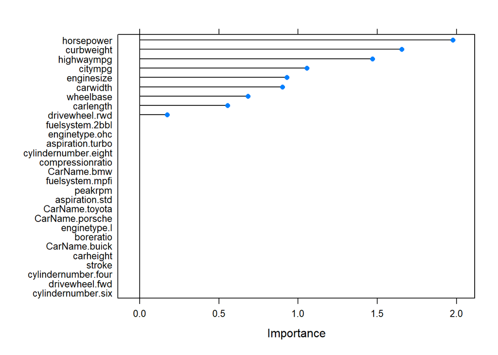

```r
plot(dt_var_imp)
```

```r
test_prediction<-predict(cartFit,newdata= test.data)
```

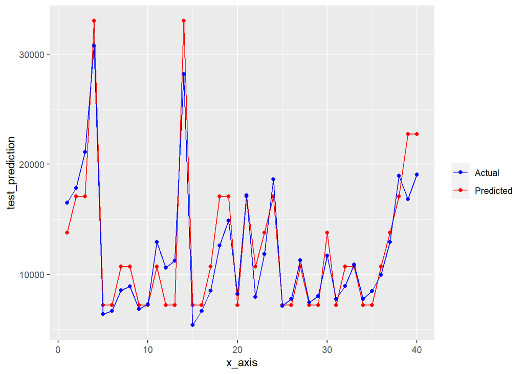

```r
numx <- nrow(test.data)
x_axis <- seq(numx)
df <- data.frame(x_axis,test_prediction,test.data$price)
#Plotting the predicted values against the actual values
g <- ggplot(df, aes(x=x_axis))
g <- g + geom_line(aes(y=test_prediction, colour="Predicted"))
g <- g + geom_point(aes(x=x_axis, y=test_prediction, colour="Predicted"))
g <- g + geom_line(aes(y=test.data$price, colour="Actual"))
g <- g + geom_point(aes(x=x_axis, y=test.data$price, colour="Actual"))
g <- g + scale_colour_manual("", values = c(Predicted="red", Actual="blue"))
g
```

MAE, MSE, RMSE and MAPE values are stored.

```r
dt_tr_1 <- MAE(as.numeric(dt_train_pred),train.data$price)
dt_tr_2 <- MSE(as.numeric(dt_train_pred),train.data$price)
dt_tr_3 <- RMSE(as.numeric(dt_train_pred),train.data$price)
dt_tr_4 <- MAPE(as.numeric(dt_train_pred),train.data$price)

dt_ts_1 <- MAE(as.numeric(test_prediction),test.data$price)
dt_ts_2 <- MSE(as.numeric(test_prediction),test.data$price)
dt_ts_3 <- RMSE(as.numeric(test_prediction),test.data$price)
dt_ts_4 <- MAPE(as.numeric(test_prediction),test.data$price)
```

Shapley Plot

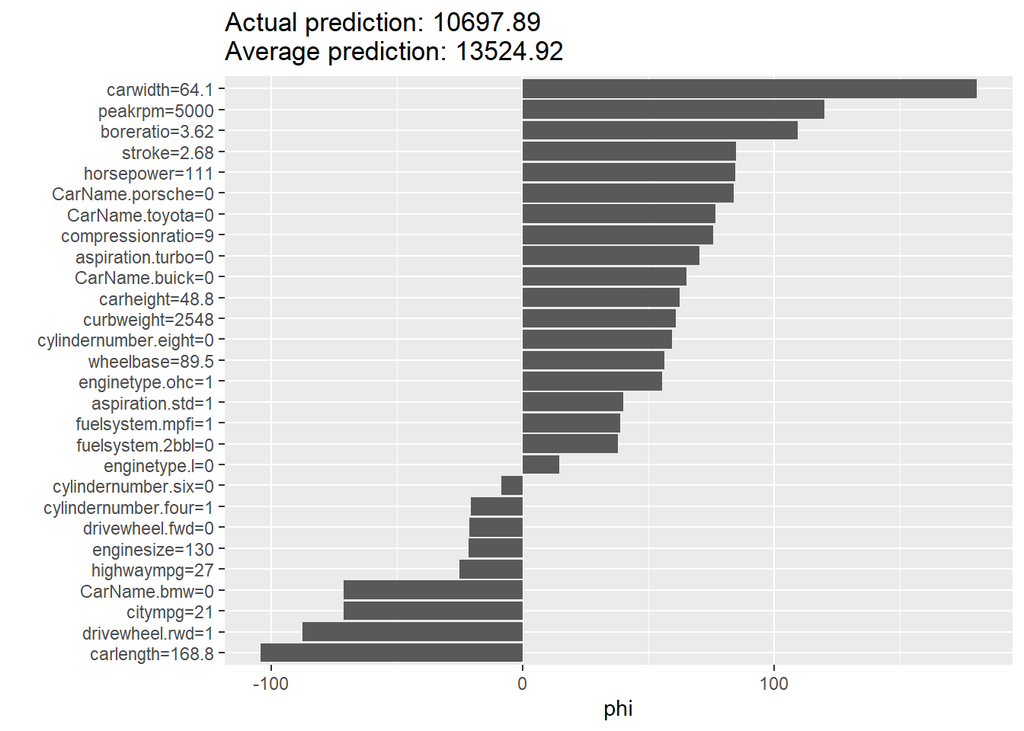

```
##
## $x
## [1] "Variables"
##
## $title
## [1] "Shap Plot"
##
## attr(,"class")
## [1] "labels"
```

```r
predictor = Predictor$new(cartFit, data = train.data[,-1], y = train.data$price)
shapley = Shapley$new(predictor, x.interest =  train.data[,-1])
plot(shapley)%>%labs(title = "Shap Plot",x = "Variables")
```

**Random Forest**

Random Forest algorithms are basically created by multiple trees which may have similar construction because of some underlying relationships of variables.

```r
set.seed(1104)
rfFit <- train(price~.,data = train.data,  method = "rf",trControl = fitcontrol,metric="RMSE")
```

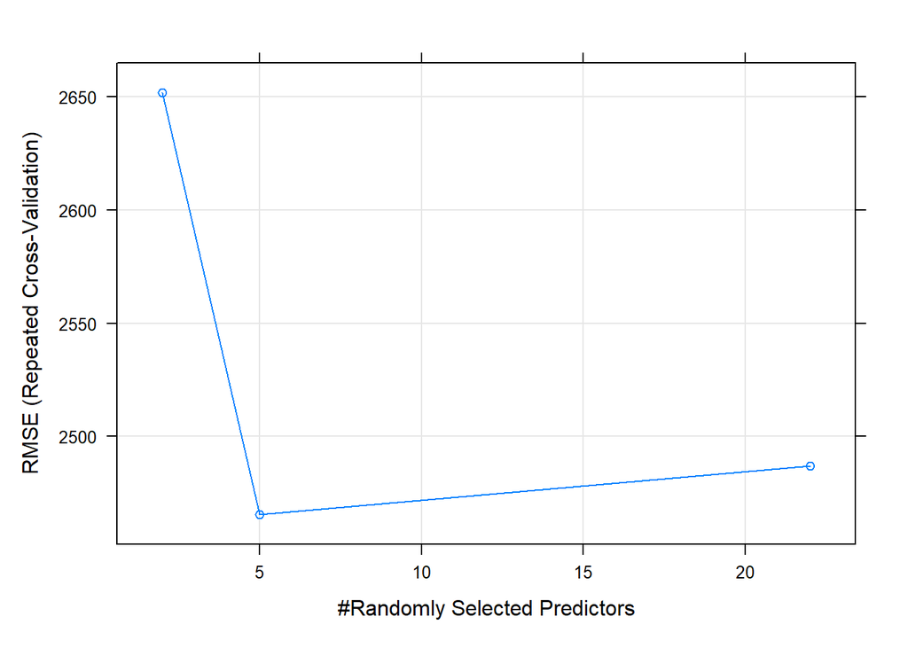

```r
plot(rfFit)
```

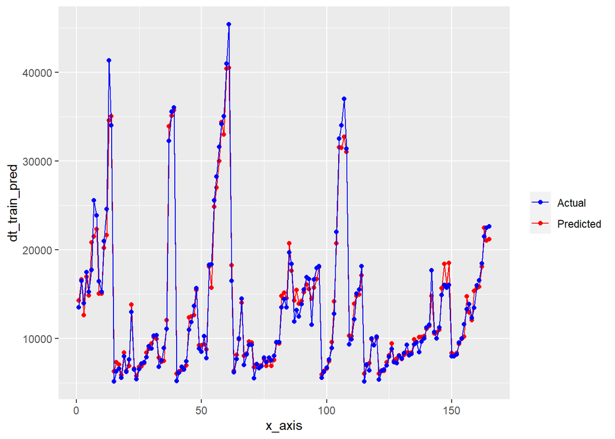

```r
numx <- nrow(train.data)
x_axis <- seq(numx)
dt_train_pred<-predict(rfFit,newdata = train.data)
df <- data.frame(x_axis, dt_train_pred,train.data$price)
#Plotting the predicted values against the actual values
g <- ggplot(df, aes(x=x_axis))
g <- g + geom_line(aes(y=dt_train_pred, colour="Predicted"))
g <- g + geom_point(aes(x=x_axis, y=dt_train_pred, colour="Predicted"))
g <- g + geom_line(aes(y=train.data$price, colour="Actual"))
g <- g + geom_point(aes(x=x_axis, y=train.data$price, colour="Actual"))
g <- g + scale_colour_manual("", values = c(Predicted="red", Actual="blue"))
g
```

```r
rf_var_imp<-varImp(rfFit, scale = FALSE)
rf_var_imp
```

```
## rf variable importance
##
##   only 20 most important variables shown (out of 28)
##
##                        Overall
## enginesize           2.093e+09
## horsepower           1.492e+09
## curbweight           1.341e+09
## carwidth             1.221e+09
## citympg              1.066e+09
## highwaympg           9.312e+08
## carlength            4.965e+08
## cylindernumber.four  4.382e+08
## boreratio            3.916e+08
## wheelbase            3.660e+08
## drivewheel.rwd       2.021e+08
## drivewheel.fwd       1.773e+08
## peakrpm              1.539e+08
## compressionratio     1.303e+08
## CarName.buick        1.173e+08
## carheight            1.005e+08
## stroke               9.365e+07
## CarName.porsche      9.079e+07
## fuelsystem.mpfi      8.929e+07
## cylindernumber.eight 4.799e+07
```

Due to its moderate MSE value for train data and the lowest MSE value for the test data, RF model is the best model for this dataset. According to Importance plot located below, enginesize is the most efficient predictor in predicting price of a car. It is followed by horsepower, curbweight and carwidth respectively.

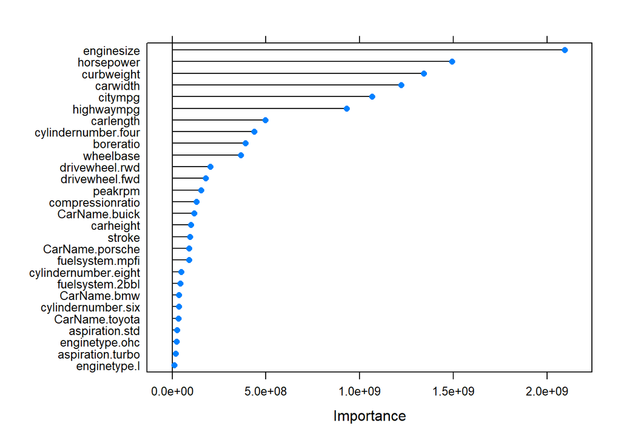

```r
plot(rf_var_imp)
```

```r
test_prediction<-predict(rfFit,newdata= test.data)
head(test_prediction)
```

```
##         2        10        14        16        23        26
## 15571.278 18069.740 18819.109 29415.470  6178.559  6333.186
```

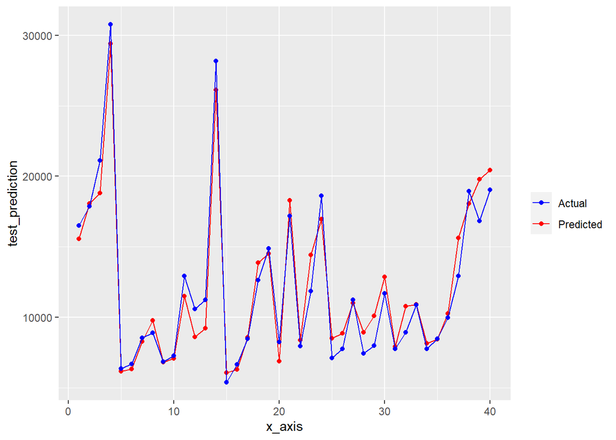

```r
numx <- nrow(test.data)
x_axis <- seq(numx)
df <- data.frame(x_axis,test_prediction,test.data$price)
#Plotting the predicted values against the actual values
g <- ggplot(df, aes(x=x_axis))
g <- g + geom_line(aes(y=test_prediction, colour="Predicted"))
g <- g + geom_point(aes(x=x_axis, y=test_prediction, colour="Predicted"))
g <- g + geom_line(aes(y=test.data$price, colour="Actual"))
g <- g + geom_point(aes(x=x_axis, y=test.data$price, colour="Actual"))
g <- g + scale_colour_manual("", values = c(Predicted="red", Actual="blue"))
g
```

MAE, MSE, RMSE and MAPE values are stored.

```r
#MAE, MSE, RMSE and MAPE values for train set.
rf_tr_1 <- MAE(as.numeric(dt_train_pred),train.data$price)
rf_tr_2 <- MSE(as.numeric(dt_train_pred),train.data$price)
rf_tr_3 <- RMSE(as.numeric(dt_train_pred),train.data$price)
rf_tr_4 <- MAPE(as.numeric(dt_train_pred),train.data$price)

#MAE, MSE, RMSE and MAPE values for train set.
rf_ts_1 <- MAE(as.numeric(test_prediction),test.data$price)
rf_ts_2 <- MSE(as.numeric(test_prediction),test.data$price)
rf_ts_3 <- RMSE(as.numeric(test_prediction),test.data$price)
rf_ts_4 <- MAPE(as.numeric(test_prediction),test.data$price)
```

Shapley Plot

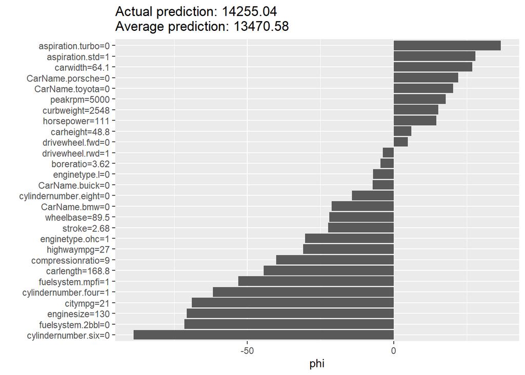

```
##
## $x
## [1] "Variables"
##
## $title
## [1] "Shap Plot"
##
## attr(,"class")
## [1] "labels"
```

```r
predictor = Predictor$new(rfFit, data = train.data[,-1], y = train.data$price)
shapley = Shapley$new(predictor, x.interest =  train.data[,-1])
plot(shapley)%>%labs(title = "Shap Plot",x = "Variables")
```

**Gradient Boosting Method**

As it can be understood from table, GBM yields excessively low performance measure values for train set indicating overfitting problem. Below train fit plot demonstrates this extreme overlapping. Hence, GBM may not be suitable for this dataset.

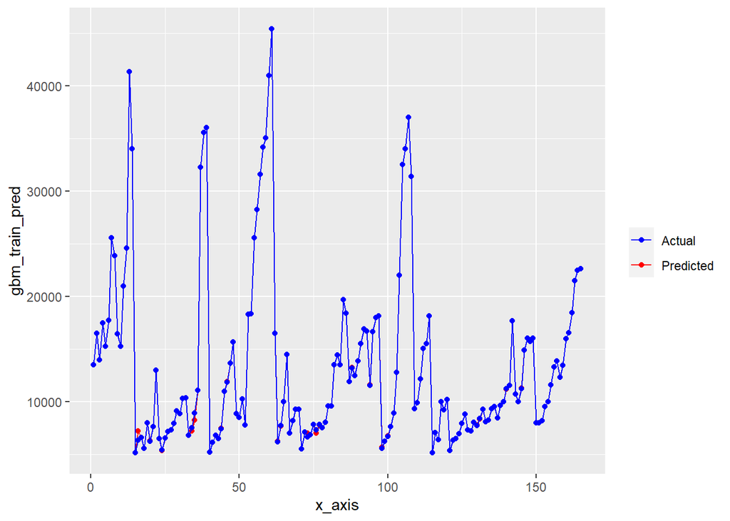

```r
numx <- nrow(train.data)
x_axis <- seq(numx)
gbm_train_pred<-predict(gbmFit,newdata = train.data)
df <- data.frame(x_axis, gbm_train_pred,train.data$price)
#Plotting the predicted values against the actual values
g <- ggplot(df, aes(x=x_axis))
g <- g + geom_line(aes(y=gbm_train_pred, colour="Predicted"))
g <- g + geom_point(aes(x=x_axis, y=gbm_train_pred, colour="Predicted"))
g <- g + geom_line(aes(y=train.data$price, colour="Actual"))
g <- g + geom_point(aes(x=x_axis, y=train.data$price, colour="Actual"))
g <- g + scale_colour_manual("", values = c(Predicted="red", Actual="blue"))
g
```

```r
gbm_var_imp<-varImp(gbmFit, scale = FALSE)
gbm_var_imp
```

```
## gbm variable importance
##
##   only 20 most important variables shown (out of 28)
##
##                       Overall
## curbweight          8.081e+09
## enginesize          7.067e+09
## carwidth            5.208e+09
## horsepower          4.538e+09
## wheelbase           1.151e+09
## carlength           1.093e+09
## boreratio           1.019e+09
## citympg             7.570e+08
## compressionratio    6.044e+08
## highwaympg          5.267e+08
## drivewheel.rwd      4.857e+08
## stroke              4.431e+08
## peakrpm             4.008e+08
## carheight           3.920e+08
## enginetype.ohc      2.647e+08
## cylindernumber.four 1.091e+08
## cylindernumber.six  8.440e+07
## drivewheel.fwd      7.177e+07
## fuelsystem.mpfi     7.176e+07
## CarName.toyota      3.682e+07
```

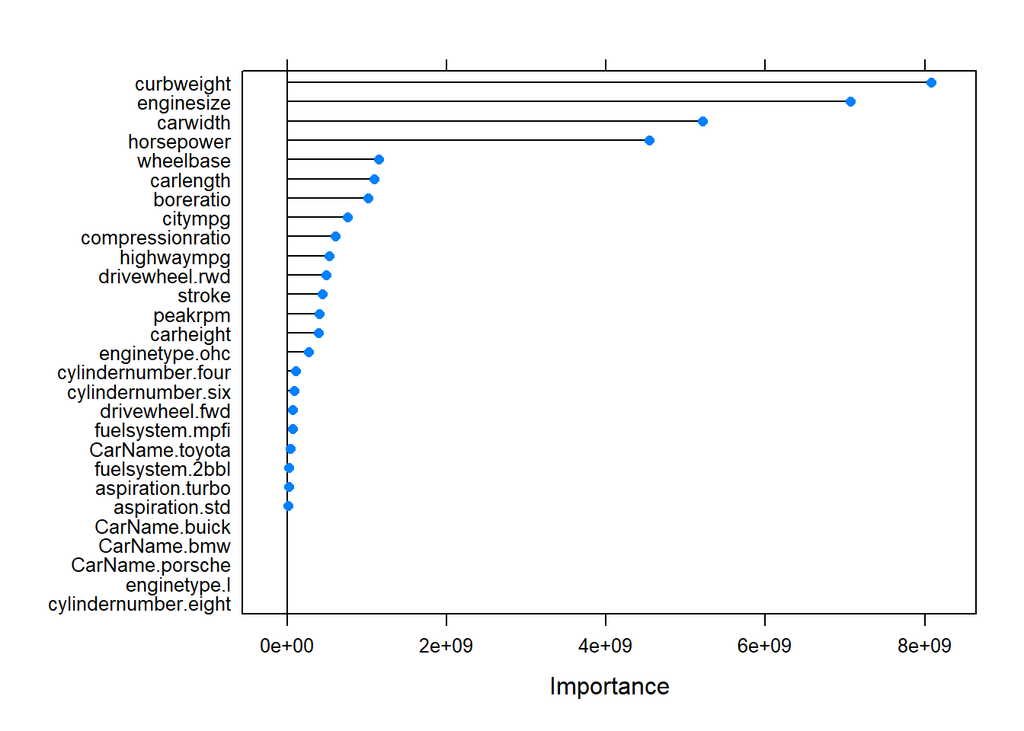

```r
plot(gbm_var_imp)
```

```r
test_prediction<-predict(gbmFit,newdata= test.data)
```

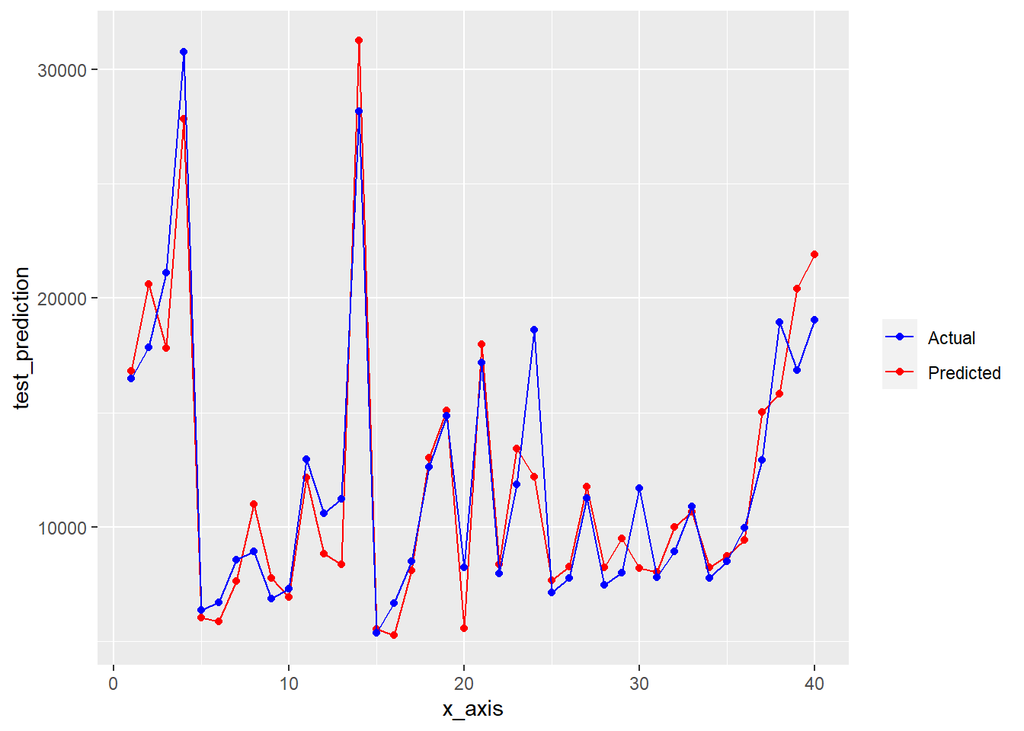

```r
numx <- nrow(test.data)
x_axis <- seq(numx)
df <- data.frame(x_axis,test_prediction,test.data$price)
#Plotting the predicted values against the actual values
g <- ggplot(df, aes(x=x_axis))
g <- g + geom_line(aes(y=test_prediction, colour="Predicted"))
g <- g + geom_point(aes(x=x_axis, y=test_prediction, colour="Predicted"))
g <- g + geom_line(aes(y=test.data$price, colour="Actual"))
g <- g + geom_point(aes(x=x_axis, y=test.data$price, colour="Actual"))
g <- g + scale_colour_manual("", values = c(Predicted="red", Actual="blue"))
g
```

MAE, MSE, RMSE and MAPE values are stored.

```r
#MAE, MSE, RMSE and MAPE values for train set.
gbm_tr_1 <- MAE(as.numeric(gbm_train_pred),train.data$price)
gbm_tr_2 <- MSE(as.numeric(gbm_train_pred),train.data$price)
gbm_tr_3 <- RMSE(as.numeric(gbm_train_pred),train.data$price)
gbm_tr_4 <- MAPE(as.numeric(gbm_train_pred),train.data$price)

#MAE, MSE, RMSE and MAPE values for train set.
gbm_ts_1 <- MAE(as.numeric(test_prediction),test.data$price)
gbm_ts_2 <- MSE(as.numeric(test_prediction),test.data$price)
gbm_ts_3 <- RMSE(as.numeric(test_prediction),test.data$price)
gbm_ts_4 <- MAPE(as.numeric(test_prediction),test.data$price)
```

Shapley Plot

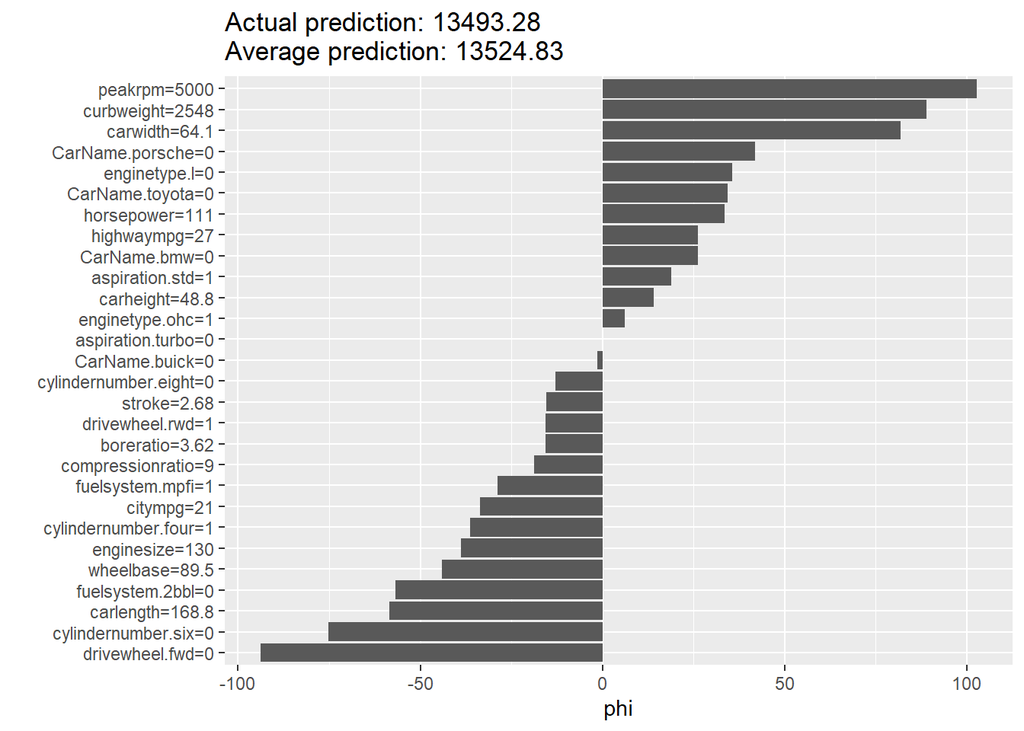

```
##
## $x
## [1] "Variables"
##
## $title
## [1] "Shap Plot"
##
## attr(,"class")
## [1] "labels"
```

```r
predictor = Predictor$new(gbmFit, data = train.data[,-1], y = train.data$price)
shapley = Shapley$new(predictor, x.interest =  train.data[,-1])
plot(shapley)%>%labs(title = "Shap Plot",x = "Variables")
```

**XGBoost**

Xgboost is a much better method than the regular boosting method in that it computes second order gradient, also known as second order partial derivatives of the loss function This situation leads to more accurate calculations regarding the direction of the gradient. XGBOOST also includes certain regularization methods such as Ridge and Lasso Regression, which provide higher model generalization.

Xgboost gives the 2nd lowest MSE value for our dataset. Again, as it was for the GBM method, most of the points overlaps in the below trait fit graph. But, it is clear that model is good in catching splashes in the test data points.

```r
xgbFit <- train(price~.,data = train.data,  method = "xgbTree",trControl = fitcontrol,metric="RMSE")
```

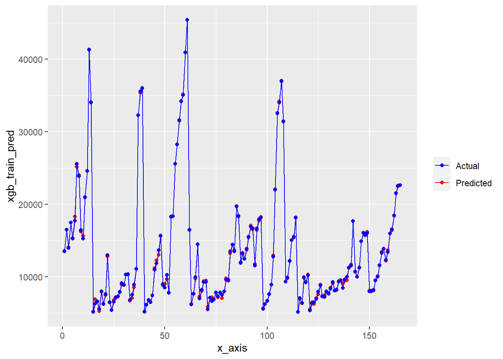

```r
numx <- nrow(train.data)
x_axis <- seq(numx)
xgb_train_pred<-predict(xgbFit,newdata = train.data)
df <- data.frame(x_axis, xgb_train_pred,train.data$price)
#Plotting the predicted values against the actual values
g <- ggplot(df, aes(x=x_axis))
g <- g + geom_line(aes(y=xgb_train_pred, colour="Predicted"))
g <- g + geom_point(aes(x=x_axis, y=xgb_train_pred, colour="Predicted"))
g <- g + geom_line(aes(y=train.data$price, colour="Actual"))
g <- g + geom_point(aes(x=x_axis, y=train.data$price, colour="Actual"))
g <- g + scale_colour_manual("", values = c(Predicted="red", Actual="blue"))
g
```

```r
xgb_var_imp<-varImp(xgbFit, scale = FALSE)
xgb_var_imp
```

```
## xgbTree variable importance
##
##   only 20 most important variables shown (out of 28)
##
##                      Overall
## cylindernumber.four 0.198764
## horsepower          0.147796
## curbweight          0.144132
## citympg             0.101472
## boreratio           0.080316
## carlength           0.066792
## enginesize          0.061523
## highwaympg          0.053729
## wheelbase           0.027329
## carwidth            0.024050
## carheight           0.018975
## stroke              0.014576
## peakrpm             0.013611
## drivewheel.rwd      0.012703
## compressionratio    0.012017
## CarName.bmw         0.009564
## CarName.buick       0.002032
## aspiration.std      0.001999
## fuelsystem.mpfi     0.001725
## cylindernumber.six  0.001516
```

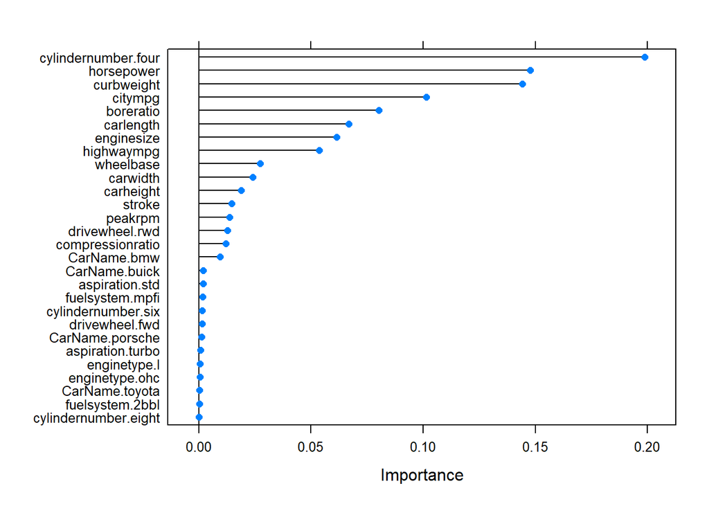

```r
plot(xgb_var_imp)
```

```r
test_prediction<-predict(xgbFit,newdata= test.data)
```

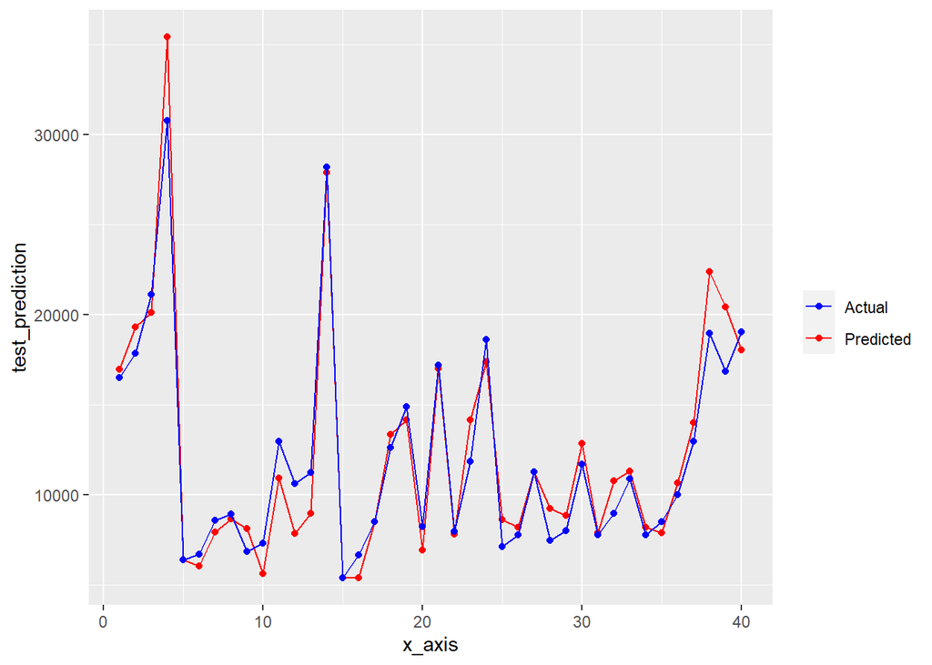

```r
numx <- nrow(test.data)
x_axis <- seq(numx)
df <- data.frame(x_axis,test_prediction,test.data$price)
#Plotting the predicted values against the actual values
g <- ggplot(df, aes(x=x_axis))
g <- g + geom_line(aes(y=test_prediction, colour="Predicted"))
g <- g + geom_point(aes(x=x_axis, y=test_prediction, colour="Predicted"))
g <- g + geom_line(aes(y=test.data$price, colour="Actual"))
g <- g + geom_point(aes(x=x_axis, y=test.data$price, colour="Actual"))
g <- g + scale_colour_manual("", values = c(Predicted="red", Actual="blue"))
g
```

MAE, MSE, RMSE and MAPE values are stored.

```r
#MAE, MSE, RMSE and MAPE values for train set.
xgb_tr_1 <- MAE(as.numeric(xgb_train_pred),train.data$price)
xgb_tr_2 <- MSE(as.numeric(xgb_train_pred),train.data$price)
xgb_tr_3 <- RMSE(as.numeric(xgb_train_pred),train.data$price)
xgb_tr_4 <- MAPE(as.numeric(xgb_train_pred),train.data$price)

#MAE, MSE, RMSE and MAPE values for train set.
xgb_ts_1 <- MAE(as.numeric(test_prediction),test.data$price)
xgb_ts_2 <- MSE(as.numeric(test_prediction),test.data$price)
xgb_ts_3 <- RMSE(as.numeric(test_prediction),test.data$price)
xgb_ts_4 <- MAPE(as.numeric(test_prediction),test.data$price)
```

Shapley Plot

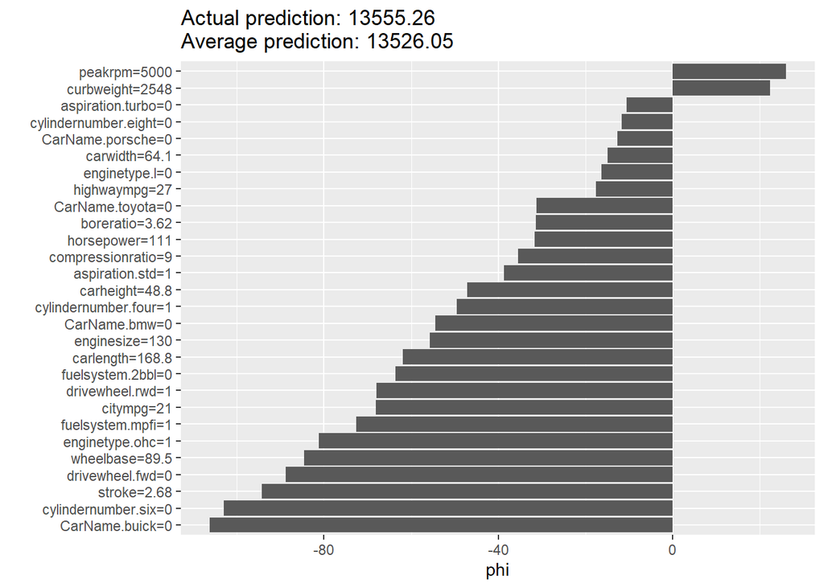

```
##
## $x
## [1] "Variables"
##
## $title
## [1] "Shap Plot"
##
## attr(,"class")
## [1] "labels"
```

```r
predictor = Predictor$new(xgbFit, data = train.data[,-1], y = train.data$price)
shapley = Shapley$new(predictor, x.interest =  train.data[,-1])
plot(shapley)%>%labs(title = "Shap Plot",x = "Variables")
```

Train set error values.

```r
all_train_results <- matrix(c(nn_tr_1, svm_tr_1, dt_tr_1, rf_tr_1, gbm_tr_1, xgb_tr_1,
                            nn_tr_2, svm_tr_2, dt_tr_2, rf_tr_2, gbm_tr_2, xgb_tr_2,
                            nn_tr_3, svm_tr_3, dt_tr_3, rf_tr_3, gbm_tr_3, xgb_tr_3,
                            nn_tr_4, svm_tr_4, dt_tr_4, rf_tr_4, gbm_tr_4, xgb_tr_4),
                            nrow = 6, ncol=4,
                            dimnames = list(c("NN", "SVM", "DT", "RF", "GBM", "XGB"),
                                            c("MAE", "MSE", "RMSE", "MAPE")))
```

```r
all_train_results
```

```
##            MAE          MSE        RMSE        MAPE
## NN  13523.9212 253259197.74 15914.11945 0.999903233
## SVM  1612.5909   5837534.31  2416.09899 0.117747490
## DT   2028.9630   9971916.00  3157.83407 0.158587960
## RF    833.3296   1612639.73  1269.89753 0.061784977
## GBM    20.7053      9903.06    99.51412 0.002821893
## XGB   124.7444     34243.00   185.04866 0.012831009
```

Test set error values.

```r
all_test_results <- matrix(c(nn_ts_1, svm_ts_1, dt_ts_1, rf_ts_1, gbm_ts_1, xgb_ts_1,
                           nn_ts_2, svm_ts_2, dt_ts_2, rf_ts_2, gbm_ts_2, xgb_ts_2,
                           nn_ts_3, svm_ts_3, dt_ts_3, rf_ts_3, gbm_ts_3, xgb_ts_3,
                           nn_ts_4, svm_ts_4, dt_ts_4, rf_ts_4, gbm_ts_4, xgb_ts_4),
                           nrow = 6, ncol=4,
                           dimnames = list(c("NN", "SVM", "DT", "RF", "GBM", "XGB"),
                                           c("MAE", "MSE", "RMSE", "MAPE")))
```

```r
all_test_results
```

```
##           MAE       MSE      RMSE       MAPE
## NN  12019.179 178011666 13342.101 0.99990060
## SVM  7643.992  61691257  7854.378 0.75745120
## DT   1760.172   5174704  2274.798 0.14654770
## RF   1052.618   1784504  1335.853 0.09114336
## GBM  1482.837   4044601  2011.119 0.11781827
## XGB  1153.350   2426761  1557.806 0.09966399
```

In this study, primary goal was predicting car prices using different machine learning algorithms. Before prediction, one of the statistical techniques, Regression was applied and interaction between covariates was checked. After applying forward selection, discarding variables leading to multicollinearity and discarding the ones that are insignificant, it is seen that there is not much difference between the fitted lines of OLS model and Robust Regression Models. In the last part, performance measures of various machine learning algorithms was compared and it was detected that Random Forest model yielded moderate train set errors and the lowest test set errors. Hence, it is determined that the RF model is most suitable one for this dataset to make car price prediction.